# R Notebook

There is a baseR way of dealing with timeseries, dealing with objects of ts class.

There are a range of packages in the tidyverse which deal with time series in a tidy format

```r
library(lubridate)
```

# Tsibble

tsibble is a tibble for time series data

Half hourly record of electricity demand in Victoria, Australia

| Time | Demand | Temperature | Date | Holiday |
| --- | --- | --- | --- | --- |
| 2012-01-01 00:00:00 | 4382.825 | 21.40 | 2012-01-01 | TRUE |
| 2012-01-01 00:30:00 | 4263.366 | 21.05 | 2012-01-01 | TRUE |
| 2012-01-01 01:00:00 | 4048.966 | 20.70 | 2012-01-01 | TRUE |
| 2012-01-01 01:30:00 | 3877.563 | 20.55 | 2012-01-01 | TRUE |
| 2012-01-01 02:00:00 | 4036.230 | 20.40 | 2012-01-01 | TRUE |
| 2012-01-01 02:30:00 | 3865.597 | 20.25 | 2012-01-01 | TRUE |
| 2012-01-01 03:00:00 | 3694.098 | 20.10 | 2012-01-01 | TRUE |
| 2012-01-01 03:30:00 | 3561.624 | 19.60 | 2012-01-01 | TRUE |
| 2012-01-01 04:00:00 | 3433.035 | 19.10 | 2012-01-01 | TRUE |
| 2012-01-01 04:30:00 | 3359.468 | 18.95 | 2012-01-01 | TRUE |

[output cut: 990 more lines]

tsibbles can have an index, which is either timedate or date or time find index variable

```r
index_var(vic_elec)
```

```
[1] "Time"
```

tsibbles can have a key,

| Country | Code | Year | GDP | Growth | CPI | Imports | Exports | Population |
| --- | --- | --- | --- | --- | --- | --- | --- | --- |
| Afghanistan | AFG | 1960 | 5.377778e+08 | NA | NA | 7.024793 | 4.132233 | 8996351 |
| Afghanistan | AFG | 1961 | 5.488889e+08 | NA | NA | 8.097166 | 4.453443 | 9166764 |
| Afghanistan | AFG | 1962 | 5.466667e+08 | NA | NA | 9.349593 | 4.878051 | 9345868 |
| Afghanistan | AFG | 1963 | 7.511112e+08 | NA | NA | 16.863910 | 9.171601 | 9533954 |
| Afghanistan | AFG | 1964 | 8.000000e+08 | NA | NA | 18.055555 | 8.888893 | 9731361 |
| Afghanistan | AFG | 1965 | 1.006667e+09 | NA | NA | 21.412803 | 11.258279 | 9938414 |
| Afghanistan | AFG | 1966 | 1.400000e+09 | NA | NA | 18.571429 | 8.571429 | 10152331 |
| Afghanistan | AFG | 1967 | 1.673333e+09 | NA | NA | 14.209827 | 6.772908 | 10372630 |
| Afghanistan | AFG | 1968 | 1.373333e+09 | NA | NA | 15.210356 | 8.899677 | 10604346 |
| Afghanistan | AFG | 1969 | 1.408889e+09 | NA | NA | 14.984227 | 10.094637 | 10854428 |

[output cut: 990 more lines]

We can use tidyverse syntax on tsibble

| Demand | Temperature | Time |
| --- | --- | --- |
| 4382.825 | 21.40 | 2012-01-01 00:00:00 |
| 4263.366 | 21.05 | 2012-01-01 00:30:00 |
| 4048.966 | 20.70 | 2012-01-01 01:00:00 |
| 3877.563 | 20.55 | 2012-01-01 01:30:00 |
| 4036.230 | 20.40 | 2012-01-01 02:00:00 |
| 3865.597 | 20.25 | 2012-01-01 02:30:00 |
| 3694.098 | 20.10 | 2012-01-01 03:00:00 |
| 3561.624 | 19.60 | 2012-01-01 03:30:00 |
| 3433.035 | 19.10 | 2012-01-01 04:00:00 |
| 3359.468 | 18.95 | 2012-01-01 04:30:00 |

[output cut: 990 more lines]

# Additional functions in tsibbles

Filter index

```r
vic_elec %>%
  filter_index("2012-01")
```

```
System time zone: "Europe/London".
It may yield an unexpected output. Please see `?filter_index` for details.
```

| Time | Demand | Temperature | Date | Holiday |
| --- | --- | --- | --- | --- |
| 2012-01-01 01:00:00 | 4048.966 | 20.70 | 2012-01-01 | TRUE |
| 2012-01-01 01:30:00 | 3877.563 | 20.55 | 2012-01-01 | TRUE |
| 2012-01-01 02:00:00 | 4036.230 | 20.40 | 2012-01-01 | TRUE |
| 2012-01-01 02:30:00 | 3865.597 | 20.25 | 2012-01-01 | TRUE |
| 2012-01-01 03:00:00 | 3694.098 | 20.10 | 2012-01-01 | TRUE |
| 2012-01-01 03:30:00 | 3561.624 | 19.60 | 2012-01-01 | TRUE |
| 2012-01-01 04:00:00 | 3433.035 | 19.10 | 2012-01-01 | TRUE |
| 2012-01-01 04:30:00 | 3359.468 | 18.95 | 2012-01-01 | TRUE |
| 2012-01-01 05:00:00 | 3331.343 | 18.80 | 2012-01-01 | TRUE |
| 2012-01-01 05:30:00 | 3304.641 | 18.65 | 2012-01-01 | TRUE |

[output cut: 990 more lines]

Add year column to tsibble

```r
vic_elec <- vic_elec %>%
  mutate(year = lubridate::year(Time))
```

# Group by are more complicated because we have to preserve the index

| Date | avg_temp |
| --- | --- |
| 2012-01-01 | 25.322917 |
| 2012-01-02 | 30.689583 |
| 2012-01-03 | 26.513542 |
| 2012-01-04 | 20.998958 |
| 2012-01-05 | 17.522917 |
| 2012-01-06 | 18.690625 |
| 2012-01-07 | 22.801042 |
| 2012-01-08 | 22.271875 |
| 2012-01-09 | 19.291667 |
| 2012-01-10 | 17.128125 |

[output cut: 990 more lines]

# Plotting time series

Often needs a group and summarise first as too much data will build an unreadable plot.

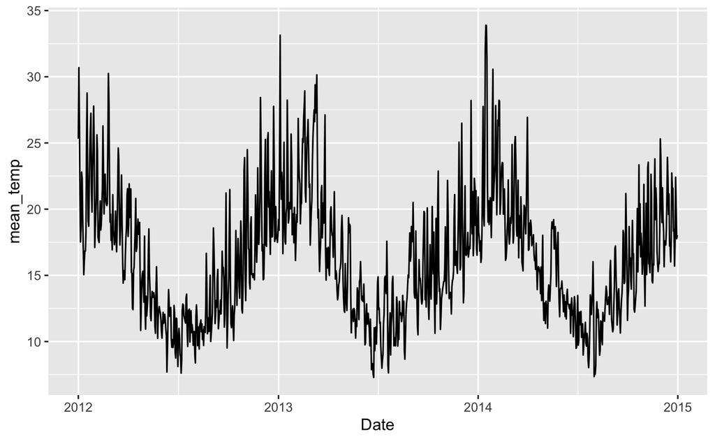

# Rolling window statistics

A different way of summarising/aggregating data Window of 10: calculate for 1:10, 2:11, 3:12, 4:13, 5:14. Gives us a similar number of values to what we started with, but smoothes out fluctuations - helps us to see trend. We also have cumulative mean.

A moving average using a window of 2000

| Time | Demand | Temperature | Date | Holiday | Year | year | mtemp_moving_avg |
| --- | --- | --- | --- | --- | --- | --- | --- |
| 2012-01-01 00:00:00 | 4382.825 | 21.40 | 2012-01-01 | TRUE | 2012 | 2012 | 20.97433 |
| 2012-01-01 00:30:00 | 4263.366 | 21.05 | 2012-01-01 | TRUE | 2012 | 2012 | 20.97590 |
| 2012-01-01 01:00:00 | 4048.966 | 20.70 | 2012-01-01 | TRUE | 2012 | 2012 | 20.97682 |
| 2012-01-01 01:30:00 | 3877.563 | 20.55 | 2012-01-01 | TRUE | 2012 | 2012 | 20.97734 |
| 2012-01-01 02:00:00 | 4036.230 | 20.40 | 2012-01-01 | TRUE | 2012 | 2012 | 20.97746 |
| 2012-01-01 02:30:00 | 3865.597 | 20.25 | 2012-01-01 | TRUE | 2012 | 2012 | 20.97729 |
| 2012-01-01 03:00:00 | 3694.098 | 20.10 | 2012-01-01 | TRUE | 2012 | 2012 | 20.97681 |
| 2012-01-01 03:30:00 | 3561.624 | 19.60 | 2012-01-01 | TRUE | 2012 | 2012 | 20.97584 |
| 2012-01-01 04:00:00 | 3433.035 | 19.10 | 2012-01-01 | TRUE | 2012 | 2012 | 20.97438 |
| 2012-01-01 04:30:00 | 3359.468 | 18.95 | 2012-01-01 | TRUE | 2012 | 2012 | 20.97282 |

[output cut: 990 more lines]

Plot moving average

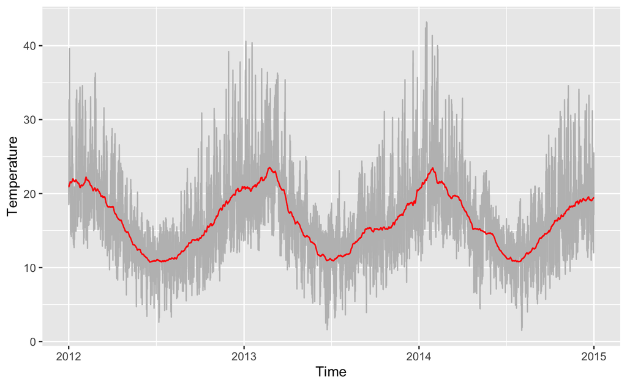

Task - moving average with window size of 200 More impacted by daily trends

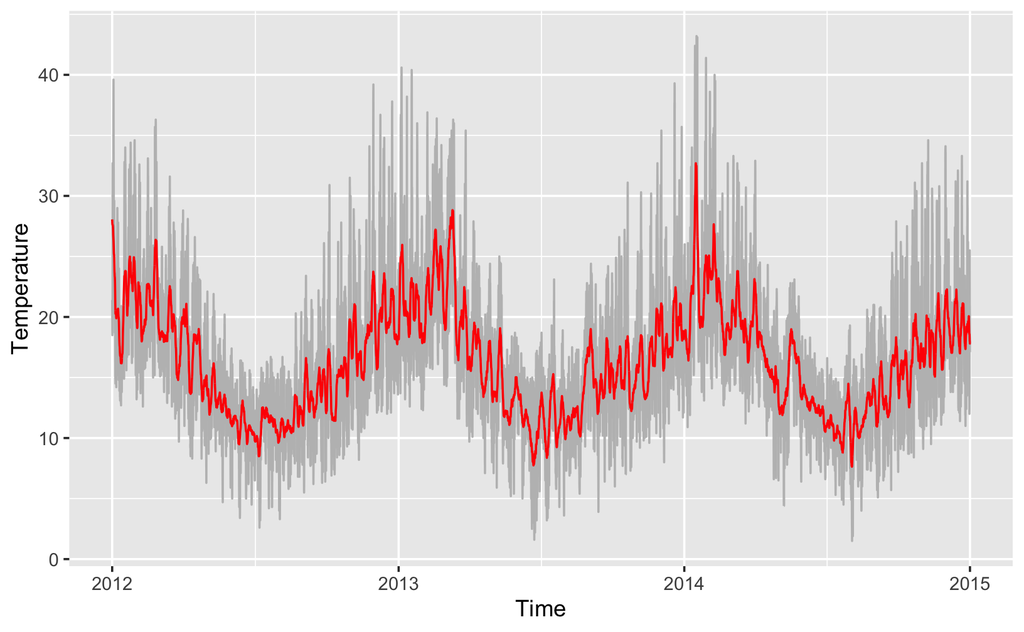

```r
vic_elec <- vic_elec %>%
  mutate(
    temp_moving_avg_200 = slide_dbl(
      Temperature,
      # functional notation, with . standing for input
      ~ mean(., na.rm = TRUE),
      .before = 100,
      .after = 100
    )
  )
vic_elec %>%
  ggplot() +
  aes(x = Time) +
  geom_line(aes(y = Temperature), col = "grey") +
  geom_line(aes(y = temp_moving_avg_200), col = "red")
```

Task - add .complete = TRUE Only calculate for the window if there are the full amount of datapoints available.

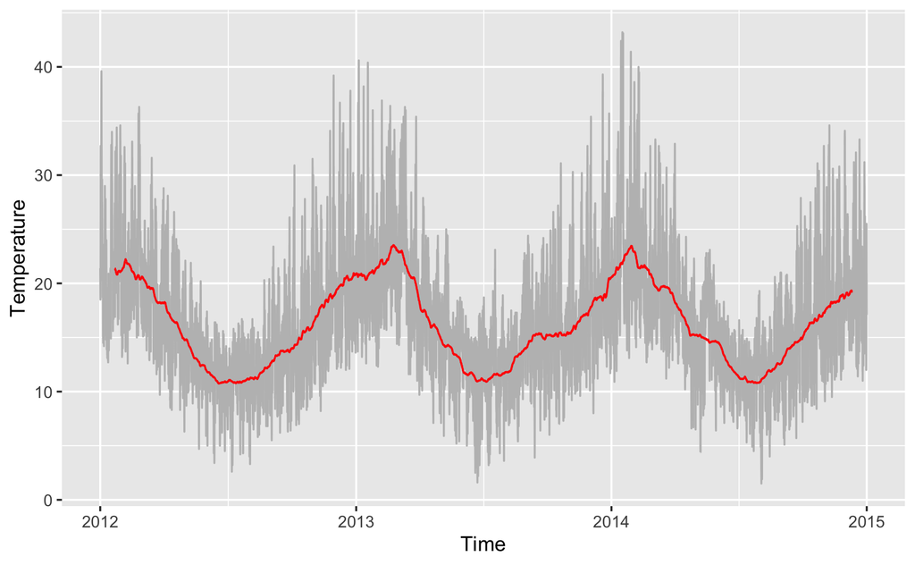

```r
vic_elec <- vic_elec %>%
  mutate(
    temp_moving_avg_200 = slide_dbl(
      Temperature,
      # functional notation, with . standing for input
      ~ mean(., na.rm = TRUE),
      .before = 1000,
      .after = 1000,
      .complete = TRUE
    )
  )
vic_elec %>%
  ggplot() +
  aes(x = Time) +
  geom_line(aes(y = Temperature), col = "grey") +
  geom_line(aes(y = temp_moving_avg_200), col = "red")
```